# beatochess no. 07 January 2025)

Beat Neuenschwander, neuenschwander.beat@gmail.com, https://github.com/beatochess/

This issue continues comments and revisions of studies published in **Shakhmatny Listok**. I am now looking more closely at prize winners published in the **EG**. A first selection of studies for which I have comments or suggestions for revisions can be found here.

# Comments and revisions

## Shakhmatny Listok (continued)

### Troitzky +0040.35c7c5 (1925). Comment, correction

Date: January 9, 2025

File: Troitzky1925a.pgn

**2. Be8** is indeed a cook, but due to a move order which differs from the one given by De Zeeuw.

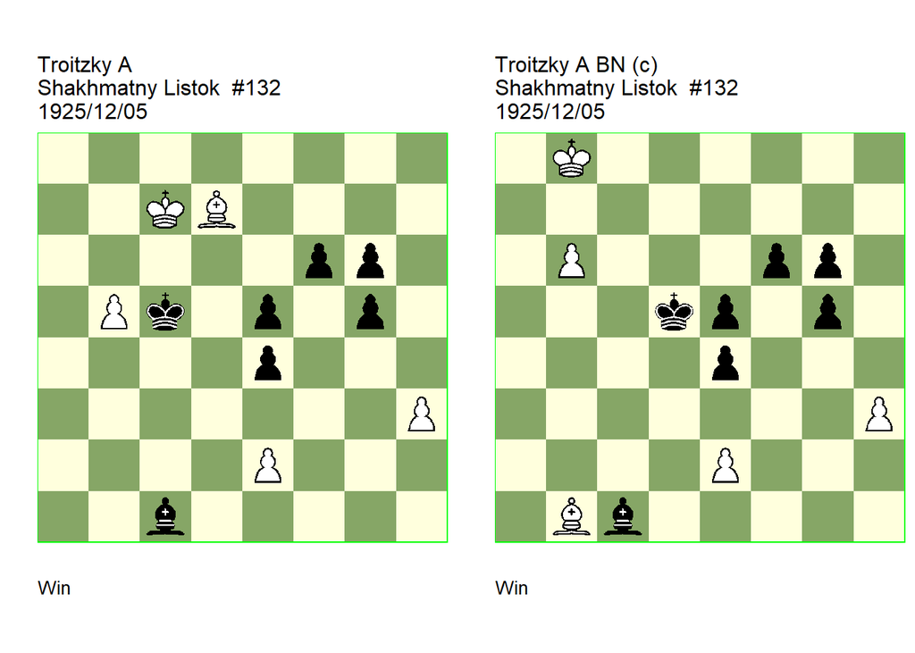

GBR: +0040.35c7c5 U2 FEN: 8/2KB4/5pp1/1Pk1p1p1/4p3/7P/4P3/2b5 w - - 0 1

Shakhmatny Listok=23 . U2: De, Zeeuw=M HHdbVI 3-11-1996. Comment/cook Neuenschwander=B beatochess 09/01/2025. **1. b6 Kd5** (1… Ba3 2. Be6!) (1… Bf4 2. e3!) **2. Ba4!** (2. Be8! **cook** MZ 2… Ke6 3. b7 comment **BN** : This does not win (3. Bf7+! **cook** **BN** 3… Ke7 4. Bxg6 e3 5. b7 Ba3 6. Kc8! (6. Bf5? Bc5 7. b8=Q Bd6+ 8. Kc8 Bxb8 9. Kxb8 Kd6 =) 6… Bd6 7. Bf5 +-) 3… Ba3 4. Bf7+ Ke7 5. Bxg6 Bd6+ 6. Kc8 e3 (6… Ke6! **cook** **BN** 7. b8=Q Bxb8 8. Kxb8 f5 =) 7. Bf5) **2… Ke6!** (2… Ba3 3. Bb3+) **3. b7 Ba3 4. Kd8 Be7+ 5. Ke8 Bd6 6. Bb3+ Kf5 7. Kd7 Bb8 8. e3 g4 9. h4 g5 10. h5 g3 11. Be6# 1-0**.

GBR: +0040.35b8d5 (c) FEN: 1K6/8/1P3pp1/3kp1p1/4p3/7P/4P3/1Bb5 w - - 0 1

correction: Neuenschwander=B beatochess 09/01/2025. **1. Kc7** (1. b7? Ba3 2. Ba2+ Kc6 3. Kc8 Bd6 4. Bf7 e3 5. Bxg6 Kd5 6. Kd7 e4 7. Bxe4+ Ke5) **1… Ke6** ( 1… Be3 2. Ba2+) (1… Ba3 2. Ba2+) **2. b7 Ba3 3. Kd8** (3. Ba2+ Ke7) **3… Bd6 4. Ba2+ Kf5 5. Kd7** (5. e3? g4 6. h4 (6. Kd7 gxh3 7. Kxd6 h2 8. b8=Q h1=Q) ( 6. Kd7 gxh3 7. Kxd6 h2 8. b8=Q h1=Q) ) **5… Bb8 6. e3 g4 7. h4 g5 8. h5 g3 9. Be6# 1-0**.

### Filaretov +0072.14e3c2 (1926). Cooks, correction

Date: January 11, 2025

File: Filaretov1926a.pgn

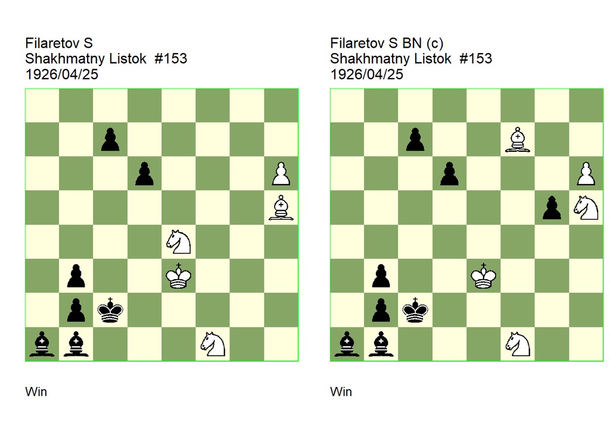

GBR: +0072.14e3c2 U2 FEN: 8/2p5/3p3P/7B/4N3/1p2K3/1pk5/bb3N2 w - - 0 1

Shakhmatny Listok=8. U2: Neuenschwander=B beatochess 11/01/2025 . **1. Ned2!** (1. Bg6? Kc1) (1. h7? Ba2 2. h8=Q (2. Bd1+) (2. Bd1+! **cook** **BN** 2… Kxd1 (2… Kc1 3. h8=Q b1=Q 4. Qh1) 3. Nc3+ Kc2 4. Nb1 Bxb1 5. h8=Q Ba2 6. Qh7+ Kc3 7. Qxc7+ Kb4 8. Qb6+ Ka4 9. Qa6+ Kb4 10. Qxd6+ Kb5 11. Nd2) 2… b1=Q 3. Qh7 Kb2) **1… Ba2 2. Nb1! Bxb1 3. h7 Ba2 4. Bg6+** (4. h8=Q! **cook** **BN** 4… b1=Q 5. Bg6+ Kc1 6. Qh6) **4… Kc1 5. Bb1! Bxb1 6. h8=Q Bc2 7. Ng3! 1-0**.

GBR: +0072.15e3c2 (c) FEN: 8/2p2B2/3p3P/6pN/8/1p2K3/1pk5/bb3N2 w - - 0 1

correction: Neuenschwander=B beatochess 11/01/2025. **1. Nd2** (1. h7? Ba2 2. Bg6+ Kc1 3. h8=Q b1=Q 4. Qh7 Qb2 5. Qxc7+ Qc3+) **1… Ba2 2. Nb1! Bxb1 3. h7 Ba2 4. Bg6+ Kc1** (4… Kd1 5. Bb1 Bxb1 6. h8=Q Ba2 (6… Bd3 7. Qc3) 7. Qd4+) **5. Bb1! Bxb1 6. h8=Q Bc2 7. Ng3 b1=Q 8. Ne2+ Kd1 9. Qh1# 1-0**.

### Filaretov +0062.22a2a6 (1926). Correction

Date: January 12, 2025

File: Filaretov1926b.pgn

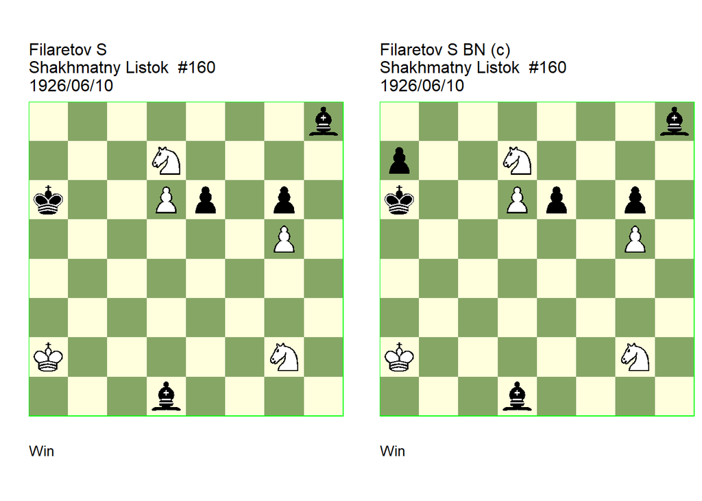

GBR: +0062.22a2a6 U1 FEN: 7b/3N4/k2Pp1p1/6P1/8/8/K5N1/3b4 w - - 0 1

Shakhmatny Listok=11 . U1: Garcia=M HHdbV#74237 24-9-2011. **1. Nb8+** (1. Nf6! **cook** MG 1… Kb6 2. Nf4 Kc6 3. Nxg6 Bg7 4. d7 Kc7 5. Ne5 Ba4 6. Ne8+ Kd8 7. Nxg7 Bxd7 8. g6 Ke7 9. Nh5 Be8 10. g7) **1… Kb7 2. d7 Kc7 3. Nf4 Bg4 4. Nxg6 Bc3** (4… e5 5. Nxh8 Bxd7 6. Nxd7 Kxd7 7. g6 Ke7 8. g7) **5. Ne5! Bxe5 6. Nc6! Kxd7** (6… Bf6 7. gxf6 Kxd7 8. f7) **7. Nxe5+ Ke7 8. Nxg4 1-0**.

GBR: +0062.23a2a6 (c) FEN: 7b/p2N4/k2Pp1p1/6P1/8/8/K5N1/3b4 w - - 0 1

correction: Neuenschwander=B beatochess 12/01/2025. **1. Nb8+** (1. Nf6 Kb7 2. Nf4 Kc6 3. Nxg6 Kxd6 4. Nxh8 Ke5) **1… Kb7 2. d7 Kc7 3. Nf4 Bg4 4. Nxg6 Bc3 5. Ne5!** (5. Kb3? Bg7 6. Ne5 Bxe5 7. Nc6 Bd1+) **5… Bxe5 6. Nc6 Kxd7 7. Nxe5+ Ke7 8. Nxg4 1-0**.

### Topcheev +4020.03e7a3 (1926). Correction

Date: January 13, 2025

File: Topcheev1926.pgn

I offer a correction in which the bK gets mated in a slightly more airy position.

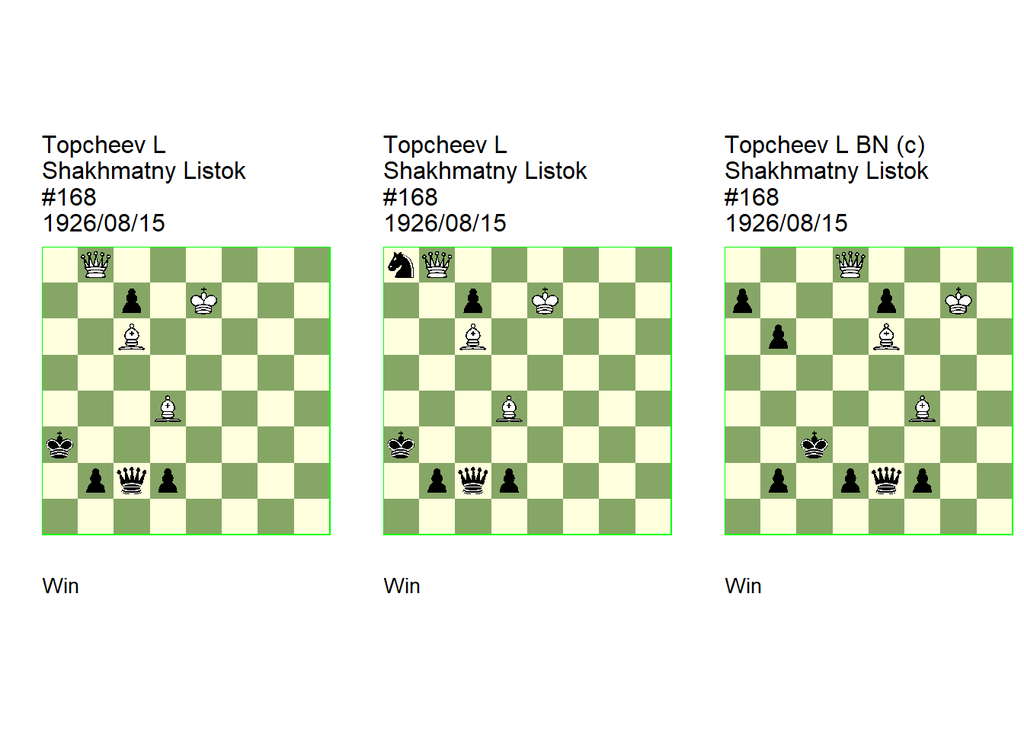

GBR: +4020.03e7a3 U2 FEN: 1Q6/2p1K3/2B5/8/3B4/k7/1pqp4/8 w - - 0 1

Shakhmatny Listok=15 . U2: Garcia=M HHdbIV#11106 19-1-2007. **1. Qa7+ Kb4 2. Bc3+! Qxc3** (2… Kxc3 3. Qc5+) **3. Qa4+** (3. Qb7+! **cook** MG 3… Ka3 4. Qa6+) (3. Qb8+! **cook** MG 3… Ka3) **3… Kc5 4. Qb5+ Kd4 5. Qd5+ Ke3 6. Qf3+ Kd4 7. Qe4+ Kc5 8. Qd5+ Kb4** (8… Kb6 9. Qb5+ Ka7 10. Qb7#) **9. Qb5+ Ka3 10. Qa4# 1-0**.

GBR: +4023.03e7a3 (c) FEN: nQ6/2p1K3/2B5/8/3B4/k7/1pqp4/8 w - - 0 1

Shakhmatny Listok=15 . correction: Garcia=M Estudios Artisticos de Ajedrez - X-60 2012. **1. Qa7+ Kb4 2. Bc3+! Qxc3** (2… Kxc3 3. Qc5+) **3. Qa4+** (3. Qb7+? Nb6) (3. Qb8+? Nb6) **3… Kc5 4. Qb5+ Kd4 5. Qd5+ Ke3 6. Qf3+ Kd4 7. Qe4+ Kc5 8. Qd5+ Kb4** (8… Kb6 9. Qb5+ Ka7 10. Qb7#) **9. Qb5+ Ka3 10. Qa4# 1-0**.

GBR: +4020.06g7c3 (c) FEN: 3Q4/p3p1K1/1p2B3/8/5B2/2k5/1p1pqp2/8 w - - 0 1

correction: Neuenschwander=B beatochess 13/01/2025. **1. Qc7+ Kd4** (1… Kb4 2. Qxe7+ Kc3 3. Qc7+ Kb4 4. Bd6+) **2. Be3+! Qxe3** (2… Kxe3 3. Qe5+ Kd3 (3… Kf3 4. Qd5+) 4. Bf5+) **3. Qc4+ Ke5 4. Qd5+ Kf4 5. Qf5+ Kg3 6. Qh3+ Kf4 7. Qg4+ Ke5 8. Qf5+ Kd4** (8… Kd6 9. Qd5+ Kc7 10. Qd7+ Kb8 11. Qc8#) **9. Qd5+ Kc3 10. Qc4# 1-0**.

### Herbstman =0264.13h5a4 (1926). Dual

Date: January 13, 2025

File: Herbstman1926a.pgn

**5. Nc5+** is a dual.

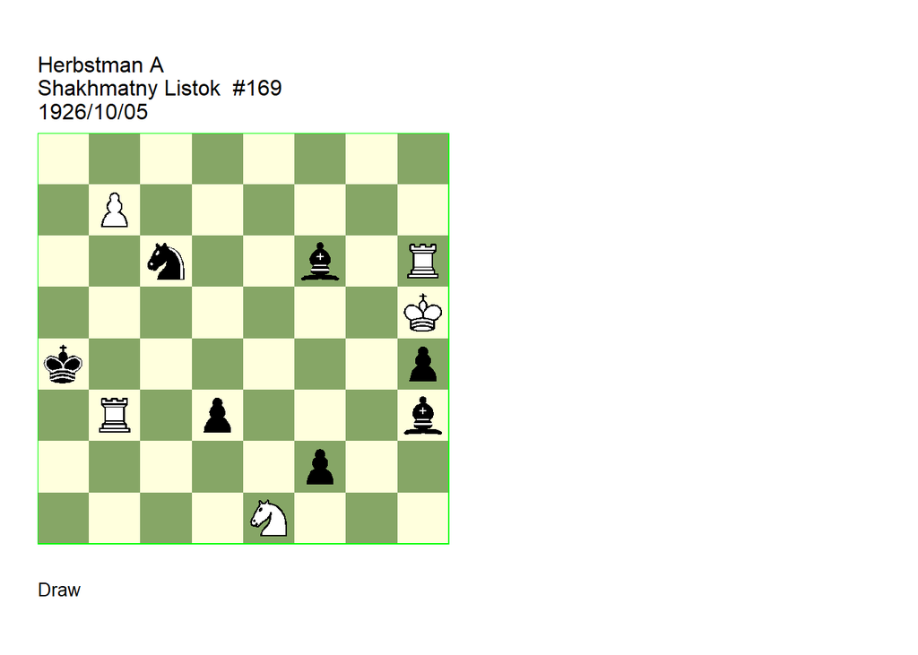

GBR: =0264.13h5a4 U2 FEN: 8/1P6/2n2b1R/7K/k6p/1R1p3b/5p2/4N3 w - - 0 1

Shakhmatny Listok=19. U2: Neuenschwander=B beatochess 13/01/2025 . **1. b8=Q Nxb8 2. Nxd3 f1=Q 3. Nc5+ Ka5 4. Nb7+ Ka6 5. Rxf6+** (5. Nc5+! **dual** **BN** 5… Ka7 6. Ra3+ Kb6 7. Rxf6+) **5… Qxf6 6. Nc5+ Ka7 7. Rb7+ Ka8 8. Rxb8+ Kxb8 9. Nd7+ Bxd7 1/2-1/2**.

### Kholmakov +0011.55c2c4 (1926). Cook, correction

Date: January 14, 2025

File: Kholmakov1926.pgn

**4. c5** leads to a large advantage for White.

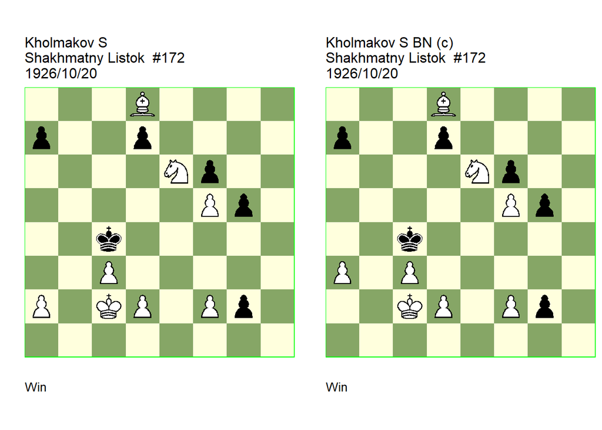

GBR: +0011.55c2c4 U2 FEN: 3B4/p2p4/4Np2/5Pp1/2k5/2P5/P1KP1Pp1/8 w - - 0 1

Shakhmatny Listok=20. U2: Neuenschwander=B beatochess 14/01/2025 . **1. d3+ Kd5! 2. c4+ Ke5 3. Bc7+ d6 4. Nd4!** (4. c5! **cook** 4… g1=Q 5. cxd6 Qxf2+ 6. Kb3 Qxf5 7. d7+ Kxe6 8. d8=Q Qb5+ 9. Ka3 Qc5+ 10. Ka4 Qc2+ 11. Kb5 Qb2+ 12. Ka6 Qxa2+ 13. Ba5 +/-) **4… Kxd4 5. Bb8 g1=Q 6. Bxa7+ Ke5 7. f4+ 1-0**.

GBR: +0011.55c2c4 (c) FEN: 3B4/p2p4/4Np2/5Pp1/2k5/P1P5/2KP1Pp1/8 w - - 0 1

correction: Neuenschwander=B beatochess 14/01/2025. **1. d3+ Kd5 2. c4+ Ke5 3. Bc7+ d6 4. Nd4!** (4. c5? g1=Q 5. cxd6 Qxf2+ 6. Kb3 Qxf5 7. d7+ Kxe6 8. d8=Q Qb5+ 9. Ka2 Qc6 10. Kb3 Qb5+ 11. Kc2 Qc5+ 12. Kd1 Qg1+ 13. Kd2 Qf2+ 14. Kc3 Qc5+) **4… Kxd4 5. Bb8 g1=Q 6. Bxa7+ Ke5 7. f4+ 1-0**.

Date: January 15, 2025

File: Gulyaev1926.pgn

**1. e6** cooks Garcia’s correction.

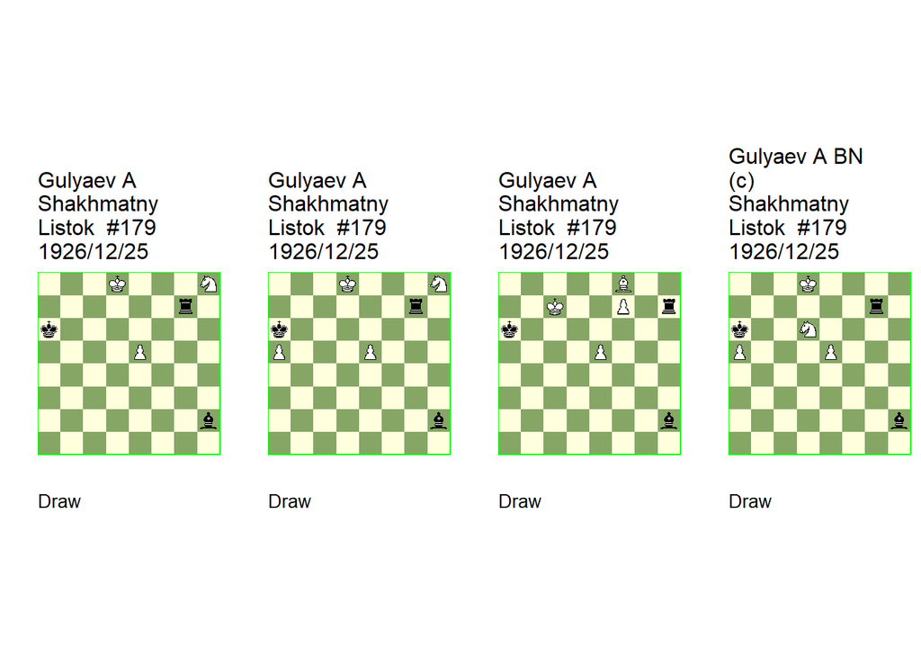

GBR: =0331.10d8a6 U3 FEN: 3K3N/6r1/k7/4P3/8/8/7b/8 w - - 0 1

Shakhmatny Listok=24 . U3: Haworth=G Bleicher=E HHdbIV#11116 1-11-2009. **1. Nf7! Rxf7** (1… Kb6! **cook** GH/EB) (1… Kb5! **cook** GH/EB) (1… Kb7! **cook** GH/EB ) (1… Bg1! **cook** GH/EB) (1… Rg8+! **cook** GH/EB) **2. e6 Bc7+ 3. Kc8 Rh7** (3… Re7) **4. e7 Rxe7 1/2-1/2**.

GBR: =0331.20d8a6 (c) U1 FEN: 3K3N/6r1/k7/P3P3/8/8/7b/8 w - - 0 1

Shakhmatny Listok=14 . correction: Garcia=M Estudios Artisticos de Ajedrez - VIII-82 2012. U1: Neuenschwander=B beatochess 15/01/2025. **1. Nf7!** (1. e6! **cook** **BN** 1… Bc7+ (1… Bd6 2. Nf7) 2. Ke8) **1… Rxf7 2. e6 Bc7+ 3. Kc8 Rh7** (3… Re7) **4. e7 Rxe7 1/2-1/2**.

GBR: =0340.20c7a6 (m) FEN: 5B2/2K2P1r/k7/4P3/8/8/7b/8 w - - 0 1

Shakhmatny Listok=24 . modification: Tkachenko=SN Edinits Shkhmatnogo Vesa#094 2015. **1. Bg7!** (1. Bd6? Rxf7+ 2. Kc6! Rb7! 3. e6 Rb6+) (1. Kd7? Rxf7+ 2. Ke8 Rh7 3. e6 Kb7! 4. e7 Kc7 5. Bg7 Bd6!) (1. Kd8? Bxe5! 2. Ke7 Rh8! 3. Bh6 Rxh6 4. f8=Q Bd6+ 5. Kf7 Bxf8) **1… Rxg7 2. Kd8! Rxf7 3. e6 Bc7+!** (3… Rf8+ 4. Kd7) **4. Kc8! Rh7 5. e7! Rxe7 1/2-1/2**.

GBR: =0331.20d8a6 (c) FEN: 3K4/6r1/k2N4/P3P3/8/8/7b/8 w - - 0 1

correction: Neuenschwander=B beatochess 15/01/2025. **1. Nf7! Rxf7 2. e6 Bc7+ 3. Kc8 Rh7 4. e7 Rxe7 1/2-1/2**.

### Kaminer +0160.32f3h5 (1926). Cook, correction

Date: January 16, 2025

File: Kaminer1926a.pgn

The correction shows a 4-corner roundtrip by the rook in the main line.

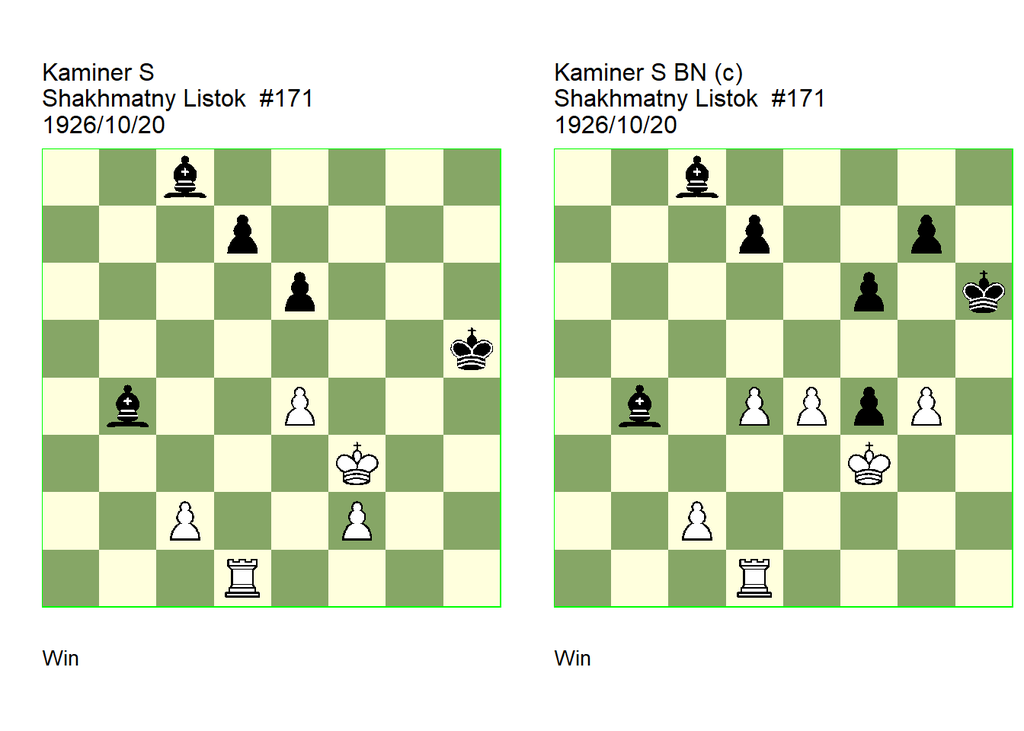

GBR: +0160.32f3h5 U2 FEN: 2b5/3p4/4p3/7k/1b2P3/5K2/2P2P2/3R4 w - - 0 1

Shakhmatny Listok=20. U2: Neuenschwander=B beatochess 16/01/2025 . **1. Rh1+ Kg5 2. Rh8** (2. Rg1+! **cook** **BN** 2… Kf6 (2… Kh4 3. Rg4+ Kh5 4. Rg8 Ba6 5. Ra8 Bf1 6. Ra1 Bh3 7. Kg3) 3. Rg8 Ba6 4. Ra8 Bf1 5. Ra1 Bh3 6. Rh1) **2… Ba6 3. Ra8** (3. Rg8+! **cook** **BN** ) **3… Bf1** (3… Bb7 4. Rb8) (3… Bc4 4. Ra4) **4. Ra1 Bh3 5. Kg3 Bg4 6. f4+ Kh5 7. Rh1+ 1-0**.

GBR: +0160.44f3h6 (c) FEN: 2b5/3p2p1/5p1k/8/1b1PPpP1/5K2/2P5/3R4 w - - 0 1

correction: Neuenschwander=B beatochess 16/01/2025 **1. Rh1+ Kg6** (1… Kg5 2. Rh5+ Kg6 3. Rh8 = **main** ) **2. Rh8 Ba6** (2… Bb7 3. Rb8) **3. Ra8 Bf1** (3… Bc4 4. Ra4) **4. Ra1 Bh3** (4… Bb5 5. Rb1) **5. Rh1 1-0**.

## Prize winners

The following three studies by Fritz, Bondarenko and Kusnetsov, and Dolgov were awarded the first three prizes in the Szachy 1973 award. The study by Fritz was cooked and eliminated and the other two were therefore awarded prizes 1 and 2.

Here are three corrections. I consider the last one a version since only the beginning of the study is identical to the one by Dolgov.

### Fritz +0243.03e1h6 (1973). Correction

Date: January 8, 2025

File: Fritz1973.pgn

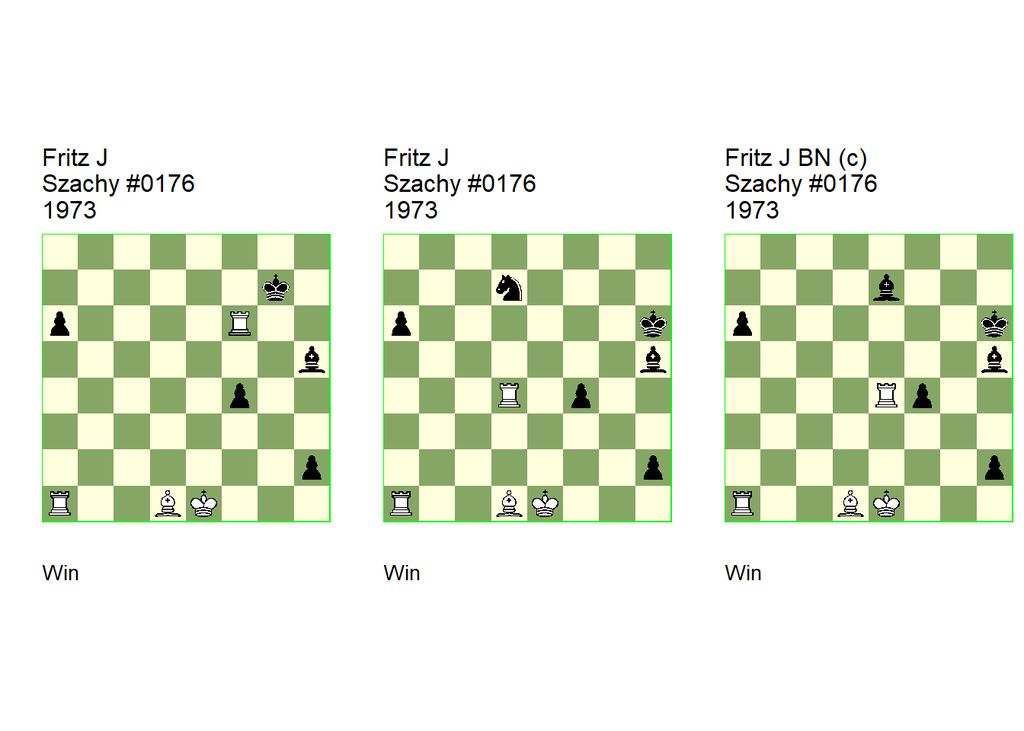

GBR: +0240.03e1g7 (c) FEN: 8/6k1/p4R2/7b/5p2/8/7p/R2BK3 w Q - 0 1

Szachy/12 (EG#02987). correction: Fritz=J 2.p Szachy#0501 Szachy=5(341) 5/1975. **1. Rg6+!** (1. Rf7+? Kg8) **1… Kf8** (1… Kh7 2. Bc2) (1… Kxg6 2. Bxh5+ Kxh5 3. Kf2) (1… Kh8 2. Rh6+ Kg7 3. Rxh5) (1… Bxg6 2. Bf3) **2. Rg8+! Ke7** (2… Kxg8 3. Bb3+ Kg7 4. Kf2) **3. Re8+!** (3. Rg7+? Kf8) **3… Kd6** ( 3… Kxe8 4. Bxh5+ Ke7 5. Kf2) **4. Re6+!** (4. Bf3? Bxf3 5. Rh8 h1=Q+ 6. Rxh1 Bxh1 7. O-O-O+ Bd5!) **4… Kc7** (4… Kxe6 5. Bb3+ Ke5 6. Kf2) **5. Rc6+! Kd8 6. Bf3! Bxf3 7. Rh6 h1=Q+ 8. Rxh1 Bxh1 9. O-O-O+! Kc7 10. Rxh1 1-0**.

GBR: +0243.03e1h6 U1 FEN: 8/3n4/p6k/7b/3R1p2/8/7p/R2BK3 w Q - 0 1

Szachy/12 (EG#02257). U1: Halski=M Szachy=2(338) 2/1975. **1. Rd6+!** (1. Rxa6+! **cook** MH 1… Nf6 2. Rxf6+ Kg7 3. Rf7+! Kg8 (3… Kh6 4. Rd6+ Kg5 5. Rd5+) 4. Rf8+! (4. Rd8+? Kxf7 5. Bxh5+ Ke7) 4… Kg7 (4… Kxf8 5. Rxf4+ Kg7 6. Rh4) 5. Rg8+! Kxg8 (5… Kh7 6. Bc2+! Kxg8 7. Be4 f3 8. Bd5+ Kg7 9. Rh4) 6. Bb3+ Kg7 7. Bd5) **1… Nf6!** (1… Kg7 2. Rxd7+ Kf8 (2… Kf6 3. Rxa6+ Kg5 4. Ra5+) 3. Rd8+ Kg7 (3… Ke7 4. Re8+!) 4. Rg8+! Kf6 5. Rxa6+ Ke7 6. Rg7+ Kf8 7. Rf7+! Kg8 8. Ra8+ Kxf7 9. Bxh5+ Kg7 10. Bf3) (1… Kg5 2. Ra5+) **2. Rxf6+ Kg7 3. Rg6+!** (3. Rf7+? Kg8) **3… Kf8** (3… Kh7 4. Bc2!) (3… Kxg6 4. Bxh5+ Kxh5 5. Kf2) **4. Rg8+! Ke7** (4… Kxg8 5. Bb3+ Kg7 6. Kf2) **5. Re8+! Kd6** (5… Kf6 6. Rxa6+ Kg7 7. Re7+ Kf8 8. Rf7+! Kg8 9. Ra8+) **6. Re6+!** (6. Bf3? Bxf3 7. Rh8 h1=Q+ 8. Rxh1 Bxh1 9. O-O-O+ Bd5!) **6… Kc7!** ( 6… Kxe6 7. Bb3+ Kd6 8. Kf2) (6… Kc5 7. Re5+ Kd6 8. Rxh5) **7. Rc6+!** (7. Rc1+? Kb7! 8. Re7+ Kb8 9. Rb1+ Ka8 10. Re8+ Ka7) **7… Kd8** (7… Kd7 8. Bf3 Bxf3 9. Rh6) (7… Kb8 8. Rb1+ Ka7 9. Rxa6+ Kxa6 10. Be2+) (7… Kb7 8. Rb1+ Ka7 9. Rxa6+! Kxa6 10. Be2+ Ka7 11. Kf2) (7… Kxc6 8. Kd2 h1=Q 9. Ba4+!) **8. Bf3! Bxf3 9. Rh6 h1=Q+ 10. Rxh1 Bxh1 11. O-O-O+! Kc7 12. Rxh1 1-0**.

GBR: +0270.03e1h6 (c) FEN: 8/4b3/p6k/7b/4Rp2/8/7p/R2BK3 w Q - 0 1

correction: Neuenschwander=B beatochess 08/01/2025. **1. Re6+** (1. Rxa6+? Bf6 2. Rxf6+ Kg7 3. Rf7+ Bxf7 (3… Kg8 4. Re8+) 4. Bf3 Bd5) **1… Bf6** (1… Kg7 2. Rxe7+ Kf8 3. Re8+ Kg7 4. Rg8+ Kf6 5. Rxa6+ Ke7 6. Rg7+ Kf8 7. Rf7+) **2. Rxf6+ Kg7 3. Rg6+ Kf8** (3… Kh7 4. Bc2) **4. Rg8+ Ke7 5. Re8+ Kd6 6. Re6+** (6. Rxa6+? Kc7) **6… Kc7 7. Rc6+ Kd7 8. Bf3 Bxf3 9. Rh6 h1=Q+ 10. Rxh1 Bxh1 11. O-O-O+ 1-0**.

### Bondarenko and Kusnetsov AP +0114.47e1g5 (1973). Correction

Date: January 17, 2025

File: BondarenkoKusnetsov1973a.pgn

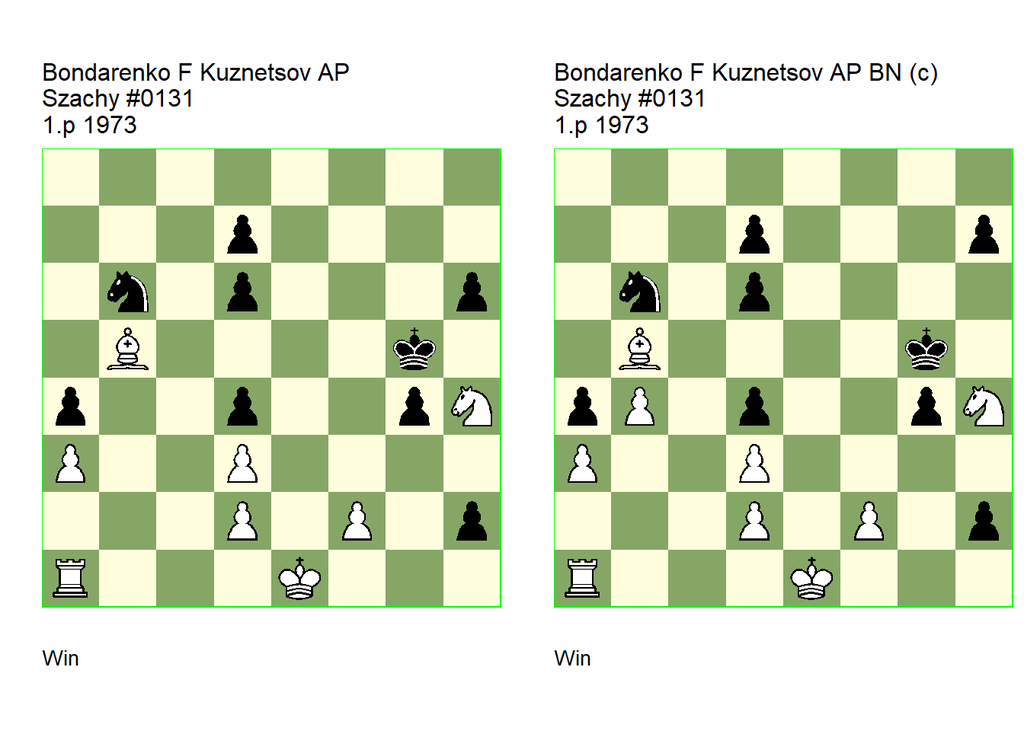

GBR: +0114.47e1g5 U3 FEN: 8/3p4/1n1p3p/1B4k1/p2p2pN/P2P4/3P1P1p/R3K3 w Q - 0 1

Szachy/9 (EG#02258). U3: Veitch=W EG=41 7/1975. **1. Nf3+! gxf3 2. O-O-O! Kg4 3. Rh1 Kh3 4. Kd1 Kg2 5. Ke1 Kxh1** (5… h5! **cook** WV 6. Ba6 Nd5 7. Bb7 Nf4 8. Bxf3+ (8. Rxh2+ Kxh2 9. Kf1 d5) (8. Be4 h4) 8… Kxf3 9. Rxh2 h4 10. Kf1 h3 11. Rh1 d5 12. Rg1 Ng2 13. Rh1 Nf4 14. Rh2 Kg4) **6. Kf1 d5!** (6… Nd5 7. Bxa4) **7. Ba6! Na8 8. Bc8 Nb6 9. Bb7 h5 10. Ba6 Na8 11. Bc8 Nb6 12. Bb7 h4 13. Ba6 Na8 14. Bc8 Nb6 15. Bb7 h3 16. Ba6 Na8** (16… Nc8! **cook** WV ) ( 16… d6 17. Bb7 Nd7 18. Bxd5 Ne5 19. Be4) **17. Bc8 Nb6 18. Bb7 1-0**.

GBR: +0114.57e1g5 (c) FEN: 8/3p3p/1n1p4/1B4k1/pP1p2pN/P2P4/3P1P1p/R3K3 w Q - 0 1

correction: Neuenschwander=B beatochess 17/01/2025. **1. Nf3+ gxf3 2. O-O-O Kh4 3. Rh1 Kh3 4. Kd1 Kg2 5. Ke1 d5 6. Ba6 Na8 7. Bc8 Nb6 8. Bb7 h6 9. Ba6 Na8 10. Bc8 Nb6 11. Bb7 h5 12. Ba6 Na8 13. Bc8 Nb6 14. Bb7 h4 15. Ba6 Na8 16. Bc8 Nb6 17. Bb7 h3 18. b5!** (18. Ba6? Na8 19. Bc8 Nc7! 20. Bb7 Nb5 21. Bxd5 Nxa3 22. Bxf3+ Kxf3 23. Rxh2 Nc2+ 24. Kd1 Nxb4 25. Rxh3+ Kxf2 26. Rh7 a3 27. Rxd7 a2 28. Ra7 Kf3) **18… Na8 19. Bxd5** (19. Bxa8? Kxh1 20. Kf1 d6) **1-0**.

### Dolgov +0500.02b5e7 (1973). Version

Date: January 21, 2025

File: Dolgov1973a.pgn

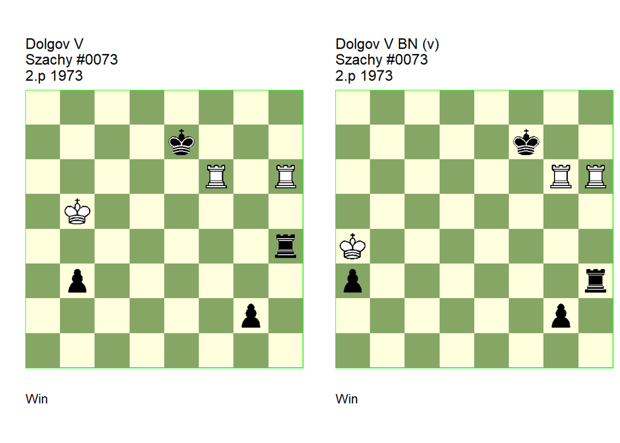

GBR: +0500.02b5e7 U2 FEN: 8/4k3/5R1R/1K6/7r/1p6/6p1/8 w - - 0 1

GBR: +0500.02a4f7 (v) FEN: 8/5k2/6RR/8/K7/p6r/6p1/8 w - - 0 1

version: Neuenschwander=B beatochess 21/01/2025. **1. Rf6+ Ke7 2. Re6+ Kd7 3. Rd6+ Kc7 4. Rc6+ Kb7 5. Rb6+ Kc7** (5… Ka7 6. Ra6+ Kb7 7. Rhb6+ Kc7 8. Rc6+ Kd7 (8… Kb7 9. Rab6+ Ka7 10. Rb1) 9. Rg6) **6. Rhc6+ Kd7 7. Rd6+ Ke7 8. Re6+ Kd7** ( 8… Kf7 9. Rbc6) **9. Rbd6+ Kc7 10. Rd1 1-0**.

### Fritz =0078.00b5d1 (1973). Cook

Date: January 21, 2025

File: Fritz1973b.pgn

The endgame after **4… Ne7+ 5. Nxe7 Bd3** is lost. According to tablebase information, approximately 50% of all 0065.00 positions are lost.

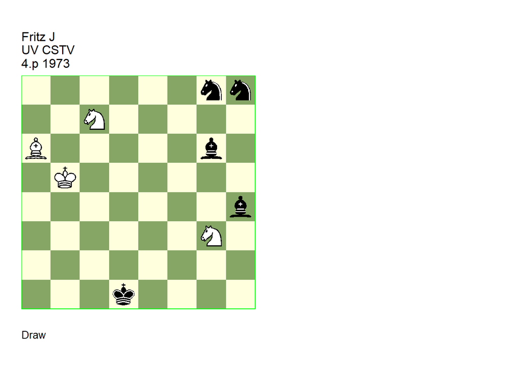

GBR: =0078.00b5d1 U3 FEN: 6nn/2N5/B5b1/1K6/7b/6N1/8/3k4 w - - 0 1

EG#02284. U3: Neuenschwander=B beatochess 21/01/2025. **1. Nf1 Bd3+ 2. Kc6 Bxa6 3. Ne3+ Ke2 4. Nf5 Bc8** (4… Ne7+! **cook** **BN** 5. Nxe7 Bd3 -+ tablebase ) **5. Nxh4 Kf2 6. Nd5 Kg3 7. Ng2 Kxg2 8. Kc7 Ba6 9. Kb6 Bc8 10. Kc7 1/2-1/2**.

Date: January 22, 2025

File: Bent1973a.pgn

According to tablebase information, the study is cooked in several ways. Note that approximately 25% of all NNB-nn positions are won.

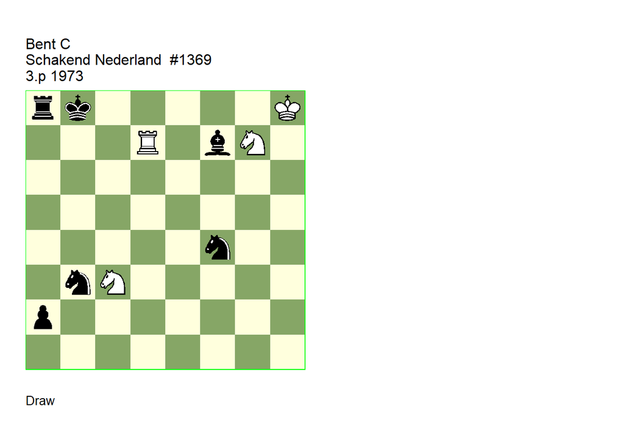

GBR: =0438.01h8b8 U2 U3 FEN: rk5K/3R1bN1/8/8/5n2/1nN5/p7/8 w - - 0 1

Schakend Nederland/9 (EG#02307). U2: Garcia=M EG=175 1/2009 U2: Garcia=M HHdbV#41922 22-9-2011. U3: Neuenschwander=B beatochess 22/01/2025. **1. Rd8+** (1. Nxa2? Ng6+) **1… Kb7** (1… Ka7 2. Rxa8+) **2. Rxa8 Kxa8 3. Nxa2 Nd5 4. Kh7 Kb7 5. Kh6** (5. Nf5 Kb6! (5… Kc6? 6. Kg7 Be6 7. Nc1 Nxc1 8. Nd4+) (5… Bh5? 6. Ng3 Bd1 7. Ne4) 6. Kg7 (6. Kh6! **cook** MG 6… Kc5 7. Kg5 Be6 8. Ng3 Kd4 9. Ne2+ Kc4 10. Ng3 Bh3 11. Kh4) 6… Be6 7. Ne7 (7. Nd6 Kc5 8. Ne4+ Kd4 9. Ng5 Bf5) 7… Nxe7 8. Kf6 Nc5 9. Kxe7 Bxa2) **5… Kb6** (5… Kc6 6. Nf5 Kc5! **cook** **BN** ) **6. Nf5** (6. Kg5! **cook** MG incorrect: tablebase ) (6. Nh5! **cook** MG incorrect: tablebase ) **6… Kc5 7. Ng3 Kd4** (7… Kc4 **main** 8. Ne2 (8. Kg5? Kd3) (8. Kg7? Be6 9. Ne2 Bg4) 8… Be6 (8… Kd3 9. Nac1+ Nxc1 10. Nxc1+) 9. Kg5! Bf7 10. Kh6 (10. Nac1? Nxc1 11. Nxc1 Nc3 12. Kf4 Kd4 13. Kf3 Bc4 14. Kf2 Ke4 15. Ke1 Ke3 16. Nd3 Kxd3) 10… Bg8 11. Kg6! (11. Kg7? Be6) 11… Be6 12. Kg5 Bh3 13. Nac1 (13. Nf4? Nxf4 14. Kxf4 Bg2 15. Ke3 Bf1) (13. Nec1? Nd4 14. Kh4 Be6 15. Kg3 Nc3 16. Kf2 Nxa2 17. Nxa2 Nb3 18. Ke2 Bg4+ 19. Ke1 Bh5 20. Kf2 Bg6 21. Ke2 Bb1) 13… Nxc1 14. Nxc1 Bf1 15. Kg4) **8. Ne2+ Kc4 9. Kg5!** (9. Nac1? Nxc1 10. Nxc1 Nc3 11. Kg5 Kd4 12. Kf4 Bd5 13. Kg3 Ke3) **9… Be6** (9… Bg8! **cook** **BN** ) **10. Kh4** (10. Nf4? Nxf4 11. Kxf4 Bg8 12. Ke3 Bh7) (10. Kg6? Bg4 11. Nac1 Nxc1 12. Nxc1 Kc3) **10… Bf5** (10… Kd3 11. Nac1+ Nxc1 12. Nxc1+ Kc2 13. Ne2) **11. Nac1** (11. Nec1 or ) (11. Kg3 or ) **1/2-1/2**.

### Dolgov =0314.10g3f7 (1973). Cook

Date: January 23, 2025

File: Dolgov1973b.pgn

In addition to the cook on move 2, White is lost in the intended main line.

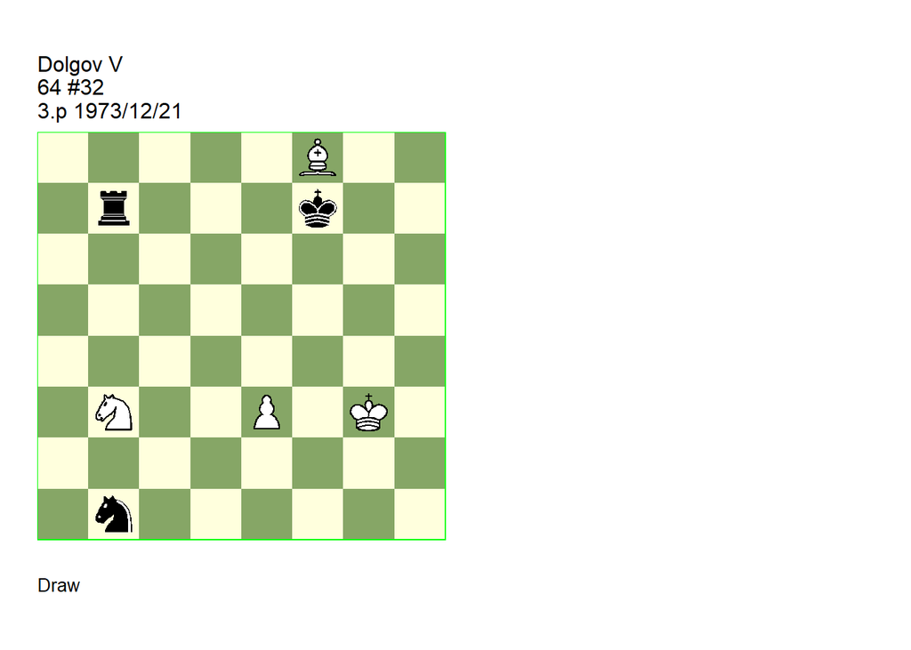

GBR: =0314.10g3f7 U2 FEN: 5B2/1r3k2/8/8/8/1N2P1K1/8/1n6 w - - 0 1

64=51(286) (EG#02379). U2: Garcia=M HHdbV#41901 6-2-2009. U3: Neuenschwander=B beatochess 23/01/2025. **1. Nc5! Rb6! 2. Kh3!** (2. Nd7 Rb5 3. Bh6 (3. Bc5! **cook** MG 3… Ke6 4. Nf8+) 3… Ke7 4. Nf8 Rh5 5. Ng6+ Kf7 6. Nh8+ Kg8) (2. Kf3? Rc6 3. Nd7 Ke8 4. Ne5 Rf6+) (2. e4? Rc6 3. Nd7 Ke8 4. Ne5 Rc3+) **2… Rc6 3. Nd7 Ke6 4. Nc5+! Kf7 5. Nd7 Rc7 6. Nc5! Nd2!** (6… Nc3 7. Bd6 Rc6 8. Nb7 Rb6 9. Be5 Ne4 10. Na5 Rb5 11. Nc4 Rc5 12. Nd6+) **7. Na6! Rc6 8. Nb8! Rb6 9. Nd7 Rb7** (9… Rb5! ccok **BN** tablebase 10. Bc5 Ke6 11. Nf8+ Kf5) **10. Nc5 Rc7** (10… Rb6 11. Na4 Ra6 12. Bb4) (10… Rb5 11. Bd6 Nc4 12. Ne4) **11. Na6! 1/2-1/2**.

### Pachman +3204.11g1g7 (1972). Cook

Date: January 23, 2025

File: Pachman1972a.pgn

**2. Re2!** cooks the study.

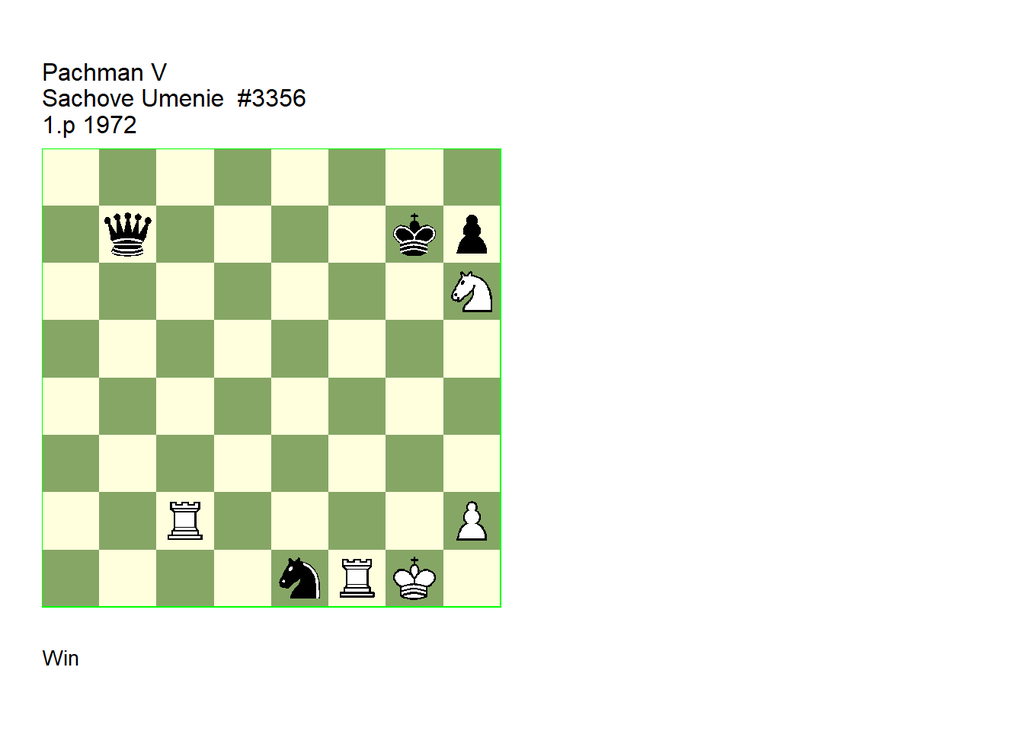

GBR: +3204.11g1g7 U2 FEN: 8/1q4kp/7N/8/8/8/2R4P/4nRK1 w - - 0 1

Sachove Umenie/11 EG#02436. U2: Neuenschwander=B beatochess 23/01/2025. **1. Nf5+ Kg6!** (1… Kf6 2. Nd6+ Nf3+ 3. Rxf3+ Qxf3 4. Rf2) **2. Nh4+** (2. Rc6+? Kg5 3. h4+ Kh5 4. Rh6+ Kg4 5. Ne3+ Kh3! 6. Rxe1 Qf3) (2. Rcf2? Qe4) (2. Re2! **cook** 2… Nd3 (2… Qa7+ 3. Ne3 Nc2 4. Rg2+ Kh5 5. Rf3) 3. Rg2+ Kh5 4. h4 Qb6+ (4… h6 5. Kh2) 5. Kh2 Qc7+ 6. Rg3 Qe5 7. Ne3 Kxh4 8. Ng2+ Kh5 9. Rf3) **2… Kh5 3. Rc5+!** (3. Rf5+? Kxh4 4. Rc4+ Kh3 5. Rh5#) **3… Kg4!** ( 3… Kxh4 4. Rf4+ Kh3 5. Rh5#) **4. Rc4+** (4. Rxe1? Kxh4) **4… Kh3!** (4… Kh5 5. Rxe1) **5. Rxe1 Qa7+ 6. Kh1!** (6. Kf1? Qf7+!) **6… Qf2!** (6… Qb7+ 7. Rce4) **7. Re3+! Qxe3 8. Ng2! Qh6!** (8… Qf2 9. Nf4+ Kg4 10. Nd3+) (8… Qe7 9. Nf4+ Kg4 10. Nd5+) **9. Rf4! Qh5** (9… Qg5 10. Rf3+ Kg4 11. Rg3+) **10. Rd4! Qh6** (10… Qg5 11. Nf4+ Kg4 12. Ne6+) **11. Rc4! Qf6** eg **12. Nf4+ Kg4 13. Nd5+ Kg5 14. Nxf6 1-0**.

### Kasparyan +0165.10a2d1 (1972). Minor dual

Date: January 23, 2025

File: Kasparyan1972a.pgn

**8. Rd8** is only a minor dual. The study is correct.

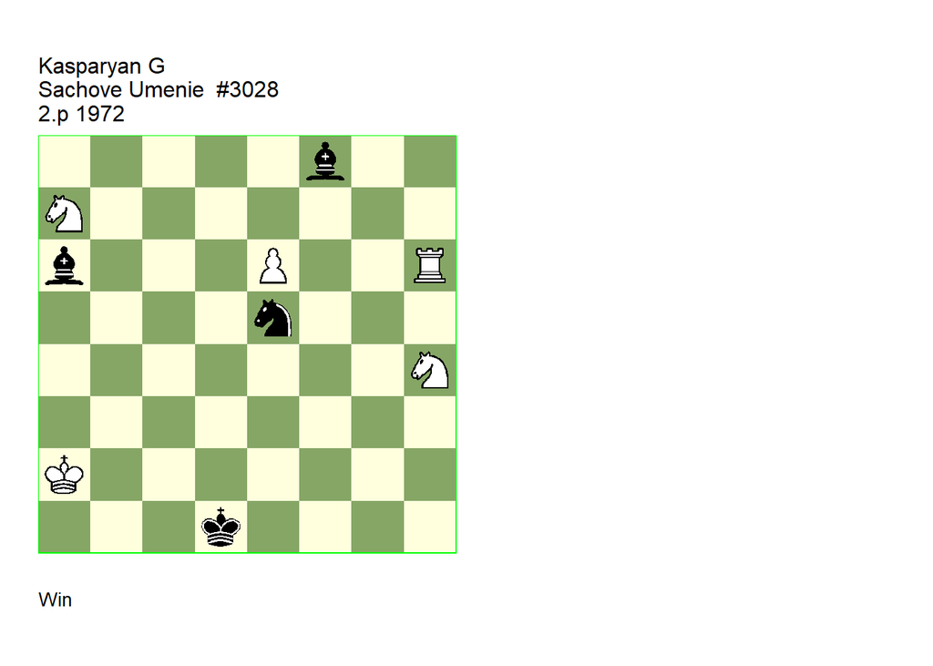

GBR: +0165.10a2d1 U2 (U2) FEN: 5b2/N7/b3P2R/4n3/7N/8/K7/3k4 w - - 0 1

Sachove Umenie/3 (EG#02437). U2: Garcia=M HHdbV#42767 6-2-2009. (U2): Neuenchwander=B beatochess 23/01/2025. **1. Rh5!** (1. Rf6? Bc5 2. Rf5 Bc4+ 3. Kb2 Bxe6) (1. e7? Bc4+ 2. Kb2 Bxe7) **1… Bc4+** (1… Bc5 2. Rxe5 Bc4+ 3. Kb1! Bd3+ 4. Kb2 Bd4+ 5. Kb3 Bxe5 6. e7 Bc2+ 7. Kc4! Ba4 8. Nb5) **2. Kb1!** (2. Kb2? Bxe6 3. Rxe5 Bg7) **2… Bd3+** (2… Ng4 3. Nf3!) (2… Nd3 3. Ng6! ( 3. Nf3? Nf4) 3… Bc5 4. e7 Bf7 5. Rh1+ Kd2 6. Nh8 Be8 7. Nc8 Nf4 8. Rf1 Nd5 9. Rf5) **3. Kb2 Bc4 4. Nf5!** (4. Nb5? Bxb5 (4… Bxe6? 5. Rxe5 Bg7 6. Nc3+!) 5. Rxe5 (5. Kc3 Bd6 6. Nf5 Bc5! 7. Ng3 Nd3! 8. Rd5 Ke1 9. Rxd3 Bxd3 10. Kxd3 Be7) 5… Bg7 6. Nf3 Bxe5+ 7. Nxe5 Be8) **4… Bxe6 5. Nd4 Bg4!** (5… Nc4+ 6. Kc3!) (5… Nd3+ 6. Kc3) **6. Rxe5 Bg7 7. Rd5!** (7. Re4? Bf3 8. Rf4 Be5 9. Rh4 Bf6! 10. Rf4 Be5 11. Rxf3 Bxd4+ 12. Kb3 Bxa7 13. Kc3 Ke2) **7… Be6! 8. Rd6!** (8. Rd8! **cook** MG minor **dual** **BN** 8… Bf6 9. Rd6 Be5 10. Rxe6 Bxd4+ = **main** ) **8… Be5 9. Rxe6!** (9. Rd8? Bf6 10. Rd6 Be5) **9… Bxd4+ 10. Kb3! Bxa7 11. Kc3! Bb8** eg (11… Bf2 12. Kd3 Kc1 13. Re2 Bh4 14. Rc2+ Kb1 15. Kc3) **12. Kd3 Bc7 13. Re7 Bd6 14. Rd7 Ba3** (14… Bg3 15. Rg7 Bf2 16. Rh7) **15. Ra7 Bb2 16. Rh7 Kc1 17. Rh1# 1-0**.

### Hoch =0500.02h6f8 (1972). Minor dual

Date: January 23, 2025

File: Hoch1972a.pgn

**4. Rg8+!** works, but it is only a minor dual.

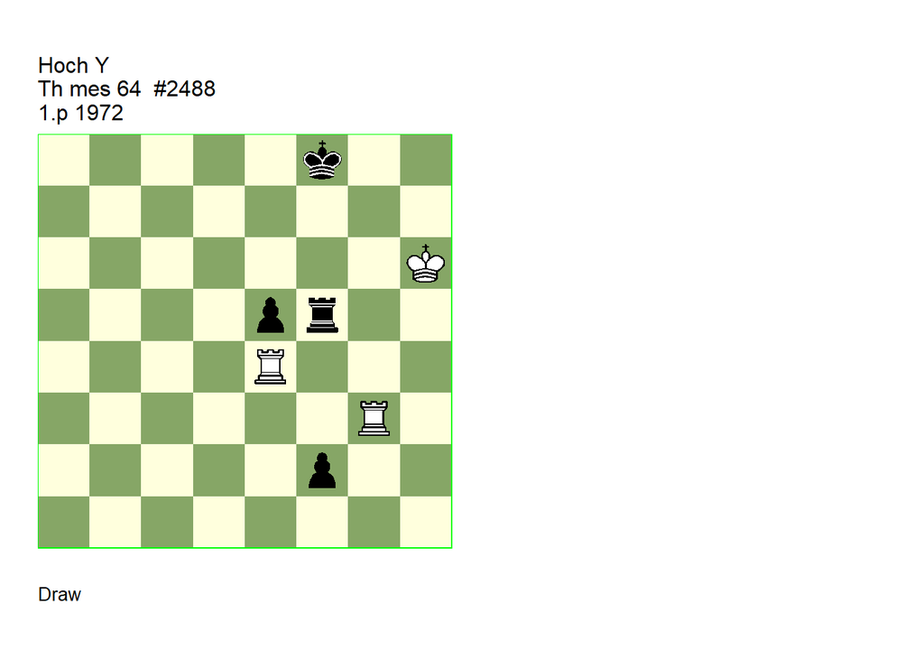

GBR: =0500.02h6f8 (U2) FEN: 5k2/8/7K/4pr2/4R3/6R1/5p2/8 w - - 0 1

Th mes 64=68 Th mes 64/10-12 EG#02452. (U2): Neuenschwander=B beatochess 23/01/2025. **1. Rxe5! Rf6+** (1… f1=Q 2. Rg8+ Kf7 3. Rf8+ Kxf8 4. Rxf5+ Qxf5) (1… Rf4 2. Rgg5! (2. Rge3? f1=Q 3. Re8+ Kf7 4. R8e7+ Kg8) 2… f1=Q (2… Rh4+ 3. Kg6) (2… Rf6+ 3. Kh7) 3. Rgf5+ Rxf5 4. Rxf5+ Qxf5) (1… Rf7 2. Rge3 Rf6+ 3. Kh7 Rf7+ 4. Kh6) **2. Kh7! Rf7+** (2… f1=Q 3. Rg8+ Kf7 4. Rg7+ Kf8 5. Rg8+) (2… Rf4 3. Rg8+ Kf7 4. Rg7+ Kf6 5. Ra5 f1=Q 6. Rg6+) **3. Kh8! Rf4 4. Rg4!** (4. Rgg5? Rh4+ 5. Rh5 f1=Q 6. Rxh4 Qf6+ 7. Kh7 Qg7#) (4. Rg8+? Kf7 5. Rg7+ (5. Rg4! **dual** **BN** ) 5… Kf6 6. Rge7 f1=Q 7. R7e6+ Kf7 8. Re7+ Kg6 9. R7e6+ Rf6) **4… Rf3** (4… f1=Q **main** 5. Rxf4+ Qxf4 6. Rf5+ Qxf5) **5. Rg3! f1=Q** (5… Rf6 6. Rg8+) **6. Rxf3+ Qxf3 7. Rf5+ Qxf5 1/2-1/2**.

Date: January 24, 2025

File: Mitrofanov1982a.pgn

**1… f4** is not a cook, but the other cook remains.

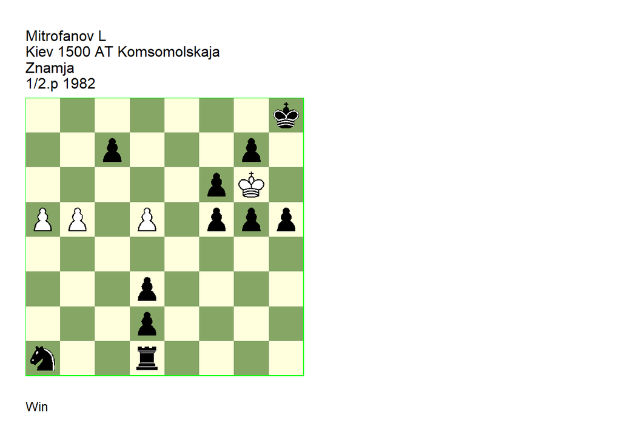

GBR: +0303.38g6h8 U3 FEN: 7k/2p3p1/5pK1/PP1P1ppp/8/3p4/3p4/n2r4 w - - 0 1

also 1/2.p Leninskoye Znamja 1982 38/41.p USSR overall champ XVI 1981-1982 Bulletin Central Chess Club USSR=9(313) 1985 (EG#05030 EG#06328). U3: Josten=G Horning=G Europa Rochade=4 4/2000. Comment Neuenschwander=B beatochess 24/01/2025. **1. b6 h4** (1… f4! **cook** GJ/GH 2. a6 (2. d6! **BN** 2… cxd6 3. a6 Re1 4. a7 Re8 5. b7 d1=Q 6. a8=Q Qe2 7. b8=Q) 2… Re1 3. a7 Re8 4. b7 d1=Q 5. a8=Q Qe2 6. b8=Q Qe4+ 7. Kf7 Qe7+) **2. a6 Re1 3. bxc7 Re8 4. d6 d1=Q 5. d7 Rf8** (5… Rg8 **main** 6. c8=Q Qb3 (6… Qh5+! **cook** GJ/GH 7. Kxh5 d2 8. a7 d1=Q+ 9. Kg6 Qd5) 7. d8=Q d2 8. Qxg8+ Qxg8 9. Qxg8+ Kxg8 10. a7) **6. d8=Q! Qh5+ 7. Kxh5 Kh7 8. Qd7 1-0**.

### Nadareishvili =0104.02e2e7 (1982). Correction

Date: January 24, 2025

File: Nadareishvili1982a.pgn

I could not fix this study as a miniature. The correction has an additional knight move in the introduction, and it is interesting to know that RN-qp with the pawn on the a- or h-file is generally a draw.

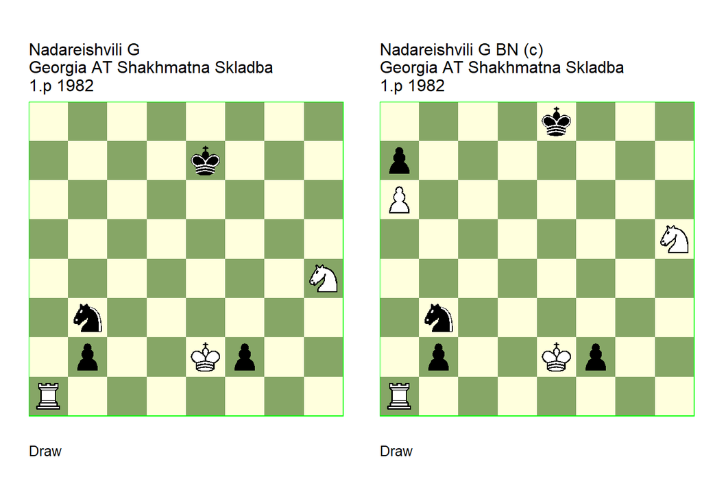

GBR: =0104.02e2e7 (v) U2 FEN: 8/4k3/8/8/7N/1n6/1p2Kp2/R7 w - - 0 1

EG#05054. U2: Garcia=M Estudios Artisticos de Ajedrez - VII-56 2012. **1. Nf5+** (1. Rb1? f1=Q+ 2. Rxf1 (2. Kxf1 Nd2+) 2… Nc1+) **1… Ke6 2. Rb1** (2. Rd1! **cook** MG 2… Nc1+ 3. Kf1 b1=Q 4. Nd4+ Ke5 5. Ne2) **2… f1=Q+ 3. Rxf1 Nc1+ 4. Kd2 b1=Q 5. Nd4+ Kd5** (5… Ke5 6. Nc6+ Ke4 7. Re1+ Kd5 8. Rxc1) **6. Nc2 Nb3+ 7. Kc3 Nc1 8. Kd2 1/2-1/2**.

GBR: =0104.13e2e7 (c) FEN: 4k3/p7/P7/7N/8/1n6/1p2Kp2/R7 w - - 0 1

correction: Neuenschwander=B beatochess 24/01/2025. **1. Ng7+** (1. Nf6+? Kf7) **1… Ke7** (1… Kf7 2. Rb1) **2. Nf5+ Ke6** (2… Kf6 3. Rb1 f1=Q+ 4. Rxf1 Nc1+ 5. Kd2 b1=Q 6. Nd4+ Kg6 7. Rxc1) **3. Rb1** (3. Rd1? Nc1+ 4. Kf1 Kxf5! 5. Rd5+ Ke4 6. Rb5 Nd3) **3… f1=Q+ 4. Rxf1 Nc1+ 5. Kd2 b1=Q 6. Nd4+ Kd5** (6… Ke5 7. Nc6+ Kd6 8. Rxc1) **7. Nc2 Nb3+ 8. Kc3 Nc1 9. Kd2 1/2-1/2**.

### Gurgenidze & Mitrofanov =3500.43d8b6 (1982). Correction

Date: January 26, 2025

File: Gurgenidze1982a.pgn

White needs more material to counter **5… Qc6+**.

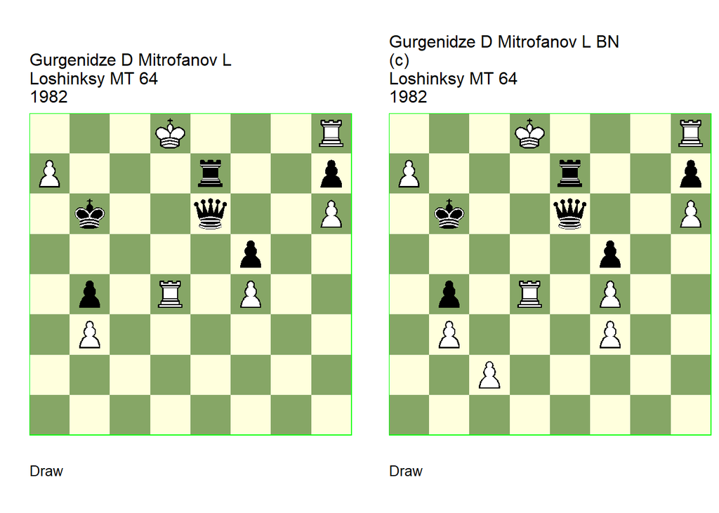

GBR: =3500.43d8b6 U3 FEN: 3K3R/P3r2p/1k2q2P/5p2/1p1R1P2/1P6/8/8 w - - 0 1

64 Shakhmatnoye Obozrenye=24(671) 64 Shakhmatnoye Obozrenye/12 (EG#05076). U3: Korolkov=V 64 Shakhmatnoye Obozrenye=14(685) 7/1983. **1. a8=Q Rd7+! 2. Rxd7 Qf6+ 3. Re7** (3. Kc8? Qc3+) **3… Qd4+ 4. Qd5!** (4. Ke8? Qxh8+ 5. Kd7 Qxa8) (4. Rd7? Qxh8+ 5. Ke7 Qxa8) **4… Qxd5+ 5. Ke8 Qa8+** (5… Qc6+! **cook** VK 6. Rd7 (6. Kf7 Qg6+ 7. Kf8 Qf6+ 8. Kg8 Qxe7 9. Rxh7) 6… Qc8+ 7. Rd8 Qe6+ 8. Kf8 Qf6+ 9. Kg8 Qxd8+ 10. Kxh7 Qf6 11. Rg8 Kc5 12. Rg6 Qf7+ 13. Rg7 Qxb3 14. Kg6 Qg3+ 15. Kf7 Qh4 16. h7 b3 17. Kg8 b2 18. Rb7 Qd8+ 19. Kg7 Qd4+ 20. Kg8 Qd5+ 21. Kf8 Qxb7) **6. Kf7 Qxh8 7. Re6+ Kc7 8. Re7+ Kd8 9. Re5! Kd7 10. Re7+ Kd6 11. Re6+ Kd5 12. Re5+ Kd4 13. Re8! Qxe8+** eg **14. Kxe8 Kc3 15. Kf7 Kxb3 16. Kg7 Ka2 17. Kxh7 b3 18. Kg6 b2 19. h7 b1=Q 20. h8=Q 1/2-1/2**.

GBR: =3500.63d8b6 (c) FEN: 3K3R/P3r2p/1k2q2P/5p2/1p1R1P2/1P3P2/2P5/8 w - - 0 1

correction: Neuenschwander=B beatochess 26/01/2025. **1. a8=Q Rd7+! 2. Rxd7 Qf6+ 3. Re7** (3. Kc8? Qc3+) **3… Qd4+ 4. Qd5!** (4. Ke8? Qxh8+ 5. Kd7 Qxa8) (4. Rd7? Qxh8+ 5. Ke7 Qxa8) **4… Qxd5+ 5. Ke8 Qa8+** (5… Qc6+ 6. Rd7 Qc8+ 7. Rd8 Qe6+ 8. Kf8 Qf6+ 9. Kg8 Qxd8+ 10. Kxh7) **6. Kf7 Qxh8 7. Re6+ Kc7 8. Re7+ Kd8 9. Re5! Kd7 10. Re7+ Kd6 11. Re6+ Kd5 12. Re5+ Kd6 13. Re6+ 1/2-1/2**.

### Marwitz =0743.30e1e8 (1981). Cook

Date: January 27, 2025

File: Marwitz1981a.pgn

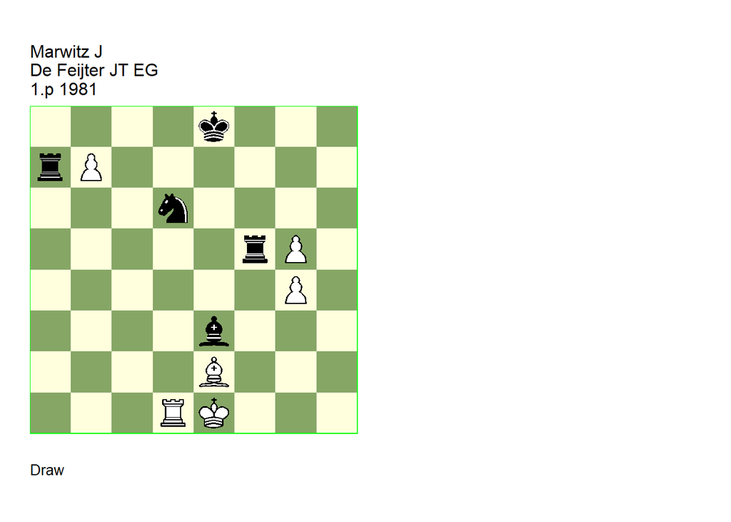

GBR: =0743.30e1e8 U2 FEN: 4k3/rP6/3n4/5rP1/6P1/4b3/4B3/3RK3 b - - 0 1

EG=76 EG/4 1984 EG#05161. U2: Neuenschwander=B beatochess 27/01/2025. **1… Bd2+!** (1… Bf2+ 2. Kf1!) (1… Bd2+) **2. Kxd2** (2. Rxd2? Ra1+ 3. Bd1 (3. Rd1 Rxd1+ 4. Kxd1 Rd5+) 3… Re5+) **2… Rd5+ 3. Ke3!** (3. Ke1? Rxd1+ 4. Bxd1 Rxb7) (3. Kc3? Rc5+ 4. Kb4 Nxb7 5. Bb5+ Kf8 6. Rd7 Rxg5 7. Bc6 Rg7) **3… Re5+ 4. Kd4!** (4. Kf4? Re4+ 5. Kf3 Ra3+ 6. Kf2 Nxb7) **4… Re4+ 5. Kc5!** (5. Kd5? Rxb7 6. Ba6 (6. Bd3 Re3 7. Kxd6 Rd7+) 6… Rd7) **5… Nxb7+ 6. Kb6! Ra5! 7. Bb5+ Kf8** (7… Kf7 8. Rd7+) **8. Rf1+!** (8. Kxb7? Rxb5+) (8. Rb1? Re5 9. g6 Kg7 10. Rb2 (10. Rb4 Re7 11. Bc6 Nd8! 12. Kxa5 Nxc6+) (10. Rb3 Nc5 11. Rc3 Rxb5+ 12. Kxb5 Ne4+) 10… Nd6! 11. Kxa5 Nc4+) (8. Rc1! **cook** **BN** 8… Rb4 (8… Re7 9. Rc8+ Kg7 10. Rb8 Re6+ 11. Bc6) 9. Rf1+ Kg7 10. Rf5 Kg6 11. Re5) **8… Kg7 9. Rb1! Re5! 10. g6! Rg5** (10… Rd5 11. Bc6) **11. Rb4!** (11. Rb2? Nd6! 12. Kxa5 Nc4+) (11. Rb3? Nc5!) **11… Re5 12. Rb1** (12. Rb3? Nc5) **12… Rc5** eg **13. Rb3! Rg5 14. Rb4! Re5 15. Rb1! 1/2-1/2**.

### Dadunasvhili +0600.54a8c7 (1979). Cook

Date: January 28, 2025

File: Dadunashvili1979a.pgn

White has a winning advantage after **6. gxf4!**.

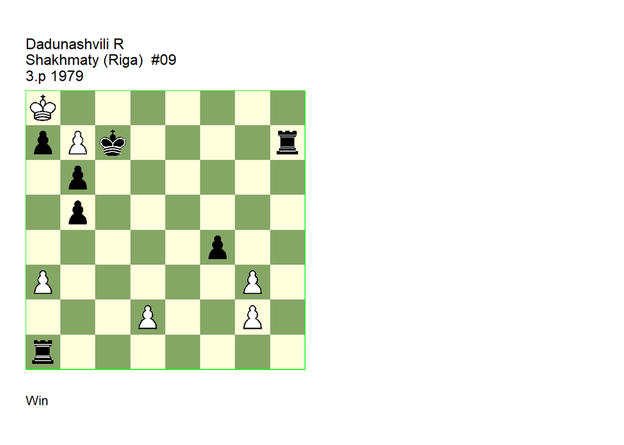

GBR: +0600.54a8c7 U2 FEN: K7/pPk4r/1p6/1p6/5p2/P5P1/3P2P1/r7 w - - 0 1

Shakhmaty (Riga)=1 Shakhmaty (Riga)/1 EG#05182. U2: Neuenschwander=B beatochess 28/01/2025. **1. b8=Q+ Kc6 2. Qe8+ Rd7 3. Kb8 Rxa3** (3… Rd1 4. Qg6+) (3… Rh1 4. d4 Rh7 5. Qe6+ Rd6 6. Qe4+) **4. Qc8+ Kd6 5. Qf8+ Re7 6. Kc8** (6. gxf4! **cook** **BN** ) **6… Ra4 7. d3 Ra2** (7… Ke6 8. gxf4) **8. Qd8+ Ke6 9. Qg8+ Rf7 10. Kd8 Rc2 11. Qg6+ Rf6 12. Qe4+ Kf7 13. Qh7+ Ke6 14. Qd7+ Ke5 15. d4+ 1-0**.

### Bordenyuk & Kuznetsov AP +3020.34f8a6 (1981). Correction

Date: January 29, 2025

File: Bordenyuk1981a.pgn

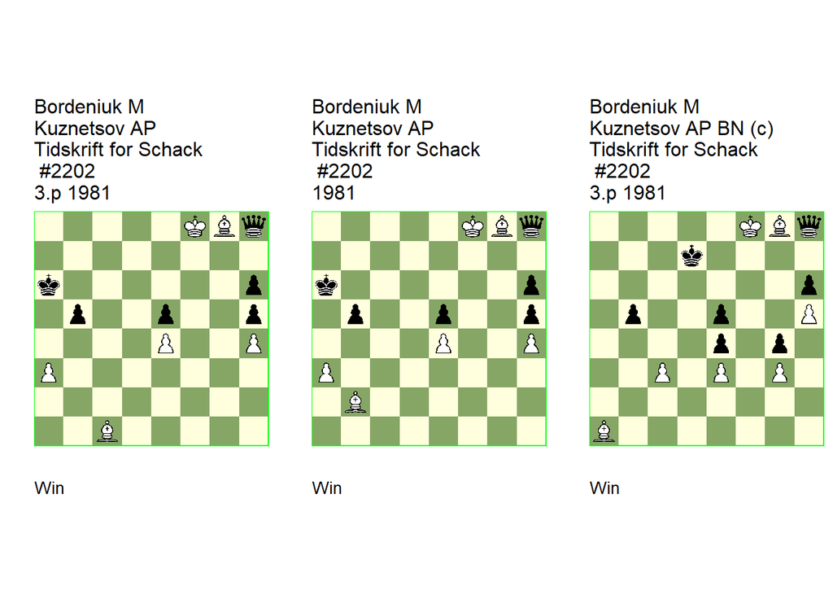

GBR: +3020.34f8a6 (c) U2 FEN: 5KBq/8/k6p/1p2p2p/4P2P/P7/8/2B5 w - - 0 1

Tidskrift for Schack=8 Tidskrift for Schack/10 (EG#05242). correction: Bordeniuk=M Kuznetsov=AP Tidskrift for Schack=5 6-7/ 1982. U2: Garcia=M HHdbV#32939 22-9-2011. **1. Kf7 b4** (1… Ka5 2. Be3!) **2. axb4 Kb5 3. Ba3** (3. Be3! **cook** MG 3… Kxb4 4. Bb6 Kc4 5. Bd8 Kd4 6. Bf6 Qxg8+ 7. Kxg8 Kxe4 8. Be7 Kf5 9. Bb4) **3… Ka4 4. b5! Kxa3 5. b6 Kb2 6. b7 Ka1 7. b8=B!** (7. b8=N? Kb2 8. Nc6 Kc3 9. Ne7 Kd4 10. Ng6 Qxg8+ 11. Kxg8 Kxe4 12. Kg7 Kf5 13. Kxh6 Kg4) (7. b8=Q? Qf6+ 8. Ke8 Qe7+ 9. Kxe7) **7… Kb2 8. Bd6! Kc3 9. Bf8 Kd4 10. Bg7 Qxg8+ 11. Kxg8 Kxe4 12. Bf8 Kf3 13. Bb4 Kg4 14. Be1 1-0**.

GBR: +3020.34f8a6 U3 FEN: 5KBq/8/k6p/1p2p2p/4P2P/P7/1B6/8 w - - 0 1

Tidskrift for Schack=8 Tidskrift for Schack/10. U3: Tidskrift for Schack=5 6-7/1982. **1. Kf7 b4** (1… Ka5! **cook** ) **2. axb4 Kb5 3. Ba3 Ka4 4. b5! Kxa3 5. b6 Kb2 6. b7 Ka1! 7. b8=B!** (7. b8=Q? Qf6+ 8. Ke8 Qe7+ 9. Kxe7) ( 7. b8=N? Kb2 8. Nc6 Kc3 9. Ne7 Kd4 10. Ng6 Qxg8+ 11. Kxg8 Kxe4 12. Kg7 Kf5 13. Kxh6 Kg4) **7… Kb2 8. Bd6! Kc3 9. Bf8 Kd4 10. Bg7 Qxg8+ 11. Kxg8 Kxe4 12. Bf8 Kf3 13. Bb4 Kg4 14. Be1 1-0**.

GBR: +3020.45f8d7 (c) FEN: 5KBq/3k4/7p/1p2p2P/4p1p1/2P1P1P1/8/B7 w - - 0 1

correction: Neuenschwander=B beatochess 29/01/2025. **1. Kf7 Kc6 2. Bb2 b4 3. cxb4 Kb5 4. Ba3!** (4. Bc3? Kc4 5. Be1 Kb5 6. Bd2 Kc4 7. Bc1 Kxb4) **4… Ka4 5. b5! Kxa3 6. b6 Kb2 7. b7 Ka1 8. b8=B!** (8. b8=Q? Qf6+ 9. Kxf6) (8. b8=N Kb2 9. Nd7 Kc3 10. Nf8 Kd3 11. Ng6 Qxg8+ 12. Kxg8 Kxe3) **1-0**.

### Kasparyan =4031.01h5h7 (1981). Cooks

Date: January 31, 2025

File: Kasparyan1981a.pgn

It seems that **1. Qc3+! Kg8 2. Kxg5!** is a cook in the correction. Moreover, in the correction with more material **4… Ke8!** is now winning due to the additional black pawn.

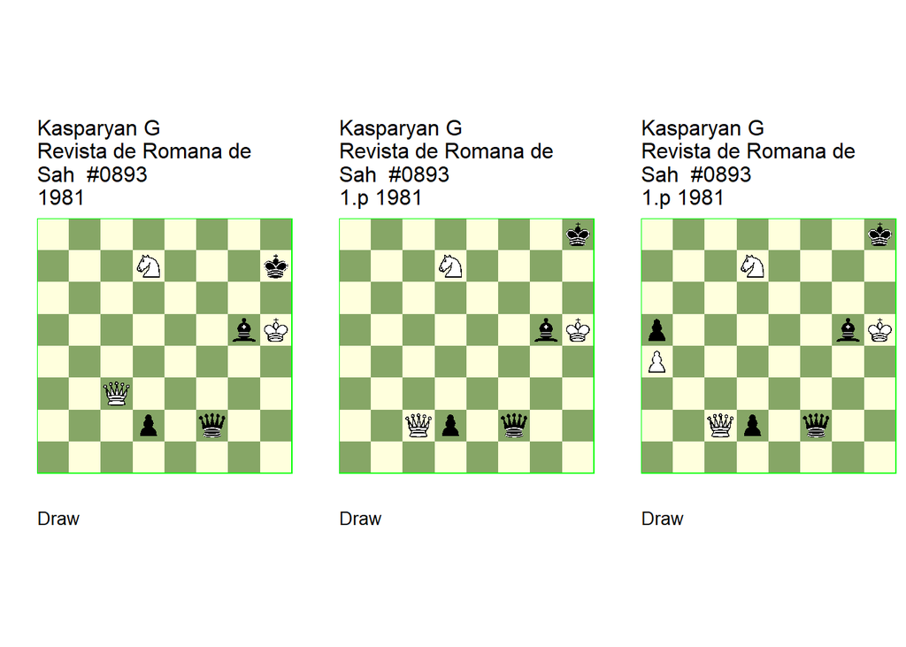

GBR: =4031.01h5h7 U1 U3 FEN: 8/3N3k/8/6bK/8/2Q5/3p1q2/8 w - - 0 1

Revista de Romana de Sah/7. U1: Raican=P Revista de Romana de Sah/12 1981 U3: Haworth=G Bleicher=E HHdbIV#49501 14-6-2010. **1. Qc2+!** (1. Qd3+ Kh8 2. Kg6 ( 2. Kxg5! **cook** PR 2… Qg1+ 3. Kf6! Qg7+ 4. Ke6 Qg4+ 5. Kf7 d1=Q 6. Qc3+ Qdd4! 7. Qc8+ Kh7 8. Nf8+! Kh6 9. Qc6+ Kh5 10. Qh1+ Qh4 11. Qf3+ Qdg4 12. Qd5+ Qhg5 13. Qh1+ Q5h4 14. Qd5+) 2… Qg1! 3. Kf7 (3. Qc3+ Bf6+ 4. Kxf6 Qg7+ ) (3. Qh3+ Bh6+! 4. Kxh6 (4. Kf5 Qg5+) 4… Qg7+!) 3… Qe3! 4. Qd5! Qe7+ 5. Kg6 Qh7+! 6. Kxg5 Qg8+) (1. Kxg5? Qg2+ 2. Kf4 d1=Q) **1… Kh8 2. Qb2+!** (2. Kg6? Qg1 3. Nf6 Bh4+! (3… Bxf6+? 4. Kxf6 d1=Q 5. Qc8+) ) **2… Kg8** (2… Kh7 3. Qb1+) **3. Qb8+ Kg7!** (3… Bd8 4. Qxd8+ Kg7 5. Qg5+ Kf7 6. Qd5+ Ke7 7. Ne5! Qh2+ 8. Kg6 Qg1+ 9. Kh7) **4. Qe5+ Kf7** (4… Bf6 **main** 5. Nxf6 d1=Q+ 6. Ng4+ Kg8 7. Qg5+ Kf8 (7… Kf7 8. Qf6+ Qxf6) 8. Qf6+ Qxf6) **5. Qd5+ Ke7** (5… Ke8 6. Ne5! Qe2+ 7. Kg6 d1=Q 8. Qf7+ Kd8 9. Nc6+) **6. Qe5+!** ( 6. Ne5? Qh4+ 7. Kg6 Qh6+ 8. Kf5 Qf6+ 9. Kg4 Qe6+!) **6… Kd8!** (6… Kxd7 7. Qf5+! Qxf5) **7. Qb8+ Kxd7 8. Qb5+! Kd6** (8… Ke7 **main** 9. Qe5+ Kf7 10. Qd5+! (10. Qf5+? Bf6!) 10… Kg7 11. Qxg5+ Kf7 12. Qf4+! Qxf4) **9. Qd3+ Kc7** (9… Kc6! **cook** GH/EB 10. Qe4+ Kb5 11. Qd3+ Kb4 12. Qb1+ Kc3 13. Qa1+ Kc2 14. Qa4+ Kb2 15. Qb4+ Kc1 16. Qc3+ Kd1 17. Qa1+ Ke2 18. Qa6+ Ke1) **10. Qc2+ Kb6 11. Qb1+ Kc7 12. Qc2+ Kd6 13. Qd3+ Ke5 14. Qf5+! Kxf5** (14… Qxf5) **1/2-1/2**.

GBR: =4031.01h5h8 (c) U3 U1 FEN: 7k/3N4/8/6bK/8/8/2Qp1q2/8 w - - 0 1

Revista de Romana de Sah/7 (EG#05310). correction: Kasparyan=G Revista de Romana de Sah/5 1982. U3: Haworth=G Bleicher=E HHdbIV#49038 1-11-2009. U1: Neuenschwander=B beatochess 31/01/2025. **1. Qb2+!** (1. Qc3+? Kg8 2. Qc8+ (2. Kxg5! **cook** **BN** ) 2… Kg7 3. Qc3+ Bf6 4. Nxf6 Qf5+ 5. Kh4 Qxf6+) (1. Kg6? Qg1 2. Nf6 Bh4+! (2… Bxf6+? 3. Kxf6 d1=Q 4. Qc8+) ) **1… Kg8** (1… Kh7 2. Qb1+) **2. Qb8+ Kg7** (2… Bd8 3. Qxd8+ Kg7 4. Qg5+ Kf7 5. Qd5+ Ke7 6. Ne5! Qh2+ 7. Kg6 Qg1+ 8. Kh7 Qh2+ (8… d1=Q 9. Nc6+) 9. Kg7) **3. Qe5+ Kf7** (3… Bf6 **main** 4. Nxf6 d1=Q+ 5. Ng4+ Kg8 6. Qg5+ Kf8 (6… Kf7 7. Qf6+ Qxf6) 7. Qf6+ Qxf6) **4. Qd5+ Ke7** (4… Ke8 5. Ne5 Qe2+ 6. Kg6 d1=Q 7. Qf7+ Kd8 8. Nc6+) **5. Qe5+** (5. Ne5? Qh4+ 6. Kg6 Qh6+ 7. Kf5 Qf6+ 8. Kg4 Qe6+) **5… Kd8 6. Qb8+ Kxd7 7. Qb5+ Kd6** (7… Ke7 **main** 8. Qe5+ Kf7 9. Qd5+ (9. Qf5+? Bf6!) 9… Kg7 10. Qxg5+ Kf7 (10… Kf8 11. Qd8+ Kf7 12. Qd7+ Kf6 13. Qd6+) 11. Qf4+ (11. Qd5+? Ke7 12. Qe5+ Kd7 13. Qd5+ Kc7) 11… Qxf4) **8. Qd3+ Kc7** (8… Kc6! **cook** GH/EB 9. Qe4+ Kb5 10. Qd3+ Kb4 11. Qb1+ Kc3 12. Qa1+ Kc2 13. Qa4+ Kb2 14. Qb4+ Kc1 15. Qc3+ Kd1) **9. Qc2+ Kb6 10. Qb1+ Kc7 11. Qc2+ Kd6 12. Qd3+ Ke5 13. Qf5+ Kxf5** (13… Qxf5) **1/2-1/2**.

GBR: =4031.12h5h8 (c) U1 FEN: 7k/3N4/8/p5bK/P7/8/2Qp1q2/8 w - - 0 1

Revista de Romana de Sah/7. correction: source unknown 1993. U3, U1: Neuenschwander=B beatochess 31/01/2025. **1. Qb2+!** (1. Qc3+? Kg8 (1… Bf6 2. Qc8+) 2. Qc8+ (2. Kxg5! **cook** **BN** 2… Qg1+ (2… d1=Q 3. Nf6+) 3. Kf5 Qf1+ 4. Kg5 d1=Q 5. Nf6+ Kf7 6. Qc7+ Ke6 7. Qc6+ Ke5 8. Qc5+ Ke6 9. Qc6+ Qd6 10. Qc8+) 2… Kg7 3. Qc3+ Bf6 4. Nxf6 Qf5+ 5. Kh4 Qxf6+) **1… Kg8 2. Qb8+ Kg7** (2… Bd8 3. Qxd8+ Kg7 4. Qg5+ Kf7 5. Qd5+ Ke7 6. Ne5 Qh2+ 7. Kg6 Qg1+ 8. Kh7 Qh2+) **3. Qe5+ Kf7** (3… Bf6 **main** 4. Nxf6 d1=Q+ 5. Ng4+ Kg8 6. Qg5+ Kf8 ( 6… Kf7 7. Qf6+ Qxf6) 7. Qf6+ Qxf6) **4. Qd5+ Ke7!** (4… Ke8 5. Ne5 Qe2+ (5… Qh4+ 6. Kg6 Qh6+ 7. Kf5 Qf6+ 8. Kg4 Qf4+ **cook** **BN** 9. Kh5 d1=Q+ 10. Qxd1 Qxe5 ) 6. Kg6 d1=Q 7. Qf7+ Kd8 8. Nc6+) **5. Qe5+!** (5. Qxg5+? Kxd7) (5. Ne5? Qh4+ 6. Kg6 Qh6+ 7. Kf5 Qf6+ 8. Kg4 Qe6+) **5… Kd8! 6. Qb8+! Kxd7 7. Qb5+! Kd6** (7… Ke7 **main** 8. Qe5+! Kf7 9. Qd5+! (9. Qf5+? Bf6) 9… Kg7 10. Qxg5+ Kf7 (10… Kf8 11. Qd8+ Kf7 12. Qd7+ Kf6 13. Qd6+) 11. Qf4+! (11. Qd5+? Ke7 12. Qe5+ Kd7 13. Qd5+ Kc7) 11… Qxf4) **8. Qd3+ Ke5** (8… Kc6 9. Qb5+ Kc7 10. Qc4+ Kb7 11. Qd5+) **9. Qf5+ Qxf5** (9… Kxf5) **1/2-1/2**.

### Sochnev +0116.33a2d3 (1976). Correction

Date: January 31, 2025

File: Sochnev1976a.pgn

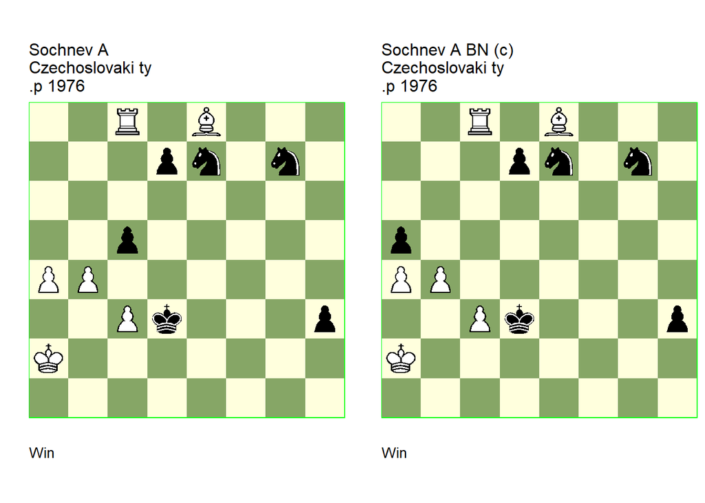

GBR: +0116.33a2d3 U3 FEN: 2R1B3/3pn1n1/8/2p5/PP6/2Pk3p/K7/8 w - - 0 1

EG#05321. U3: Garcia=M EG=177 7/2009. **1. Rd8 h2 2. Bxd7 h1=Q** (2… Nh5! **cook** MG 3. Bc6+ (3. Be6+ Kxc3) (3. Bg4+ Kxc3) 3… Kxc3) **3. Bc6+ Nd5 4. Rxd5+ Kxc3 5. Rxc5+** (5. Rd3+? Kxd3 6. Bxh1 cxb4 7. Kb3 Ne6 8. Kxb4 Kd4 9. a5 Nc5 10. Kb5 Ne6 11. Kb6 Nc5) **5… Kxb4 6. Rb5+ Kxa4 7. Bd7 Qh3 8. Rf5+** (8. Rd5+? Qxd7) **8… Kb4 9. Rf4+ Kc5 10. Bxh3 1-0**.

GBR: +0116.33a2d3 (c) FEN: 2R1B3/3pn1n1/8/p7/PP6/2Pk3p/K7/8 w - - 0 1

correction: Neuenschwander=B beatochess 31/01/2025. **1. Rd8 h2 2. Bxd7 h1=Q** ( 2… Nh5 3. Bc6+ Kxc3 4. Bb7 Kxb4 5. Rh8 Nf6 6. Rh4+) **3. Bc6+ Nd5 4. Rxd5+ Kxc3** (4… Kc2 5. Rd2+) **5. Rc5+** (5. Rd3+ Kxd3 6. Bxh1 Kc4) **5… Kxb4 6. Rb5+ Kxa4 7. Bd7! Qh3 8. Rf5+ Kb4 9. Rf4+ 1-0**.